# Question

In a school, there are 115 students. Each student can be in bike club, crochet club, both, or neither. The amounts are represented in the Venn diagram below.

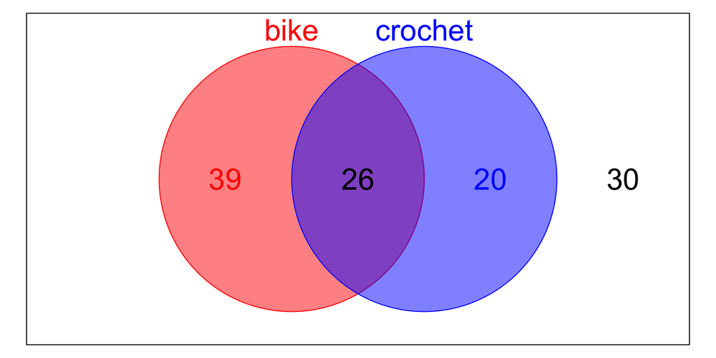

Let $B$ represent the event that a randomly selected student is in bike club, and let $C$ represent the event that a random student is in crochet club.

- $P(C|B)=$ ##ANSWER1##
- $P(B\cup C)=$ ##ANSWER2##
- $P(B)=$ ##ANSWER3##
- $P(C)=$ ##ANSWER4##
- $P(B\cap C)=$ ##ANSWER5##
- $P(B|C)=$ ##ANSWER6##
- Are events $B$ and $C$ independent? ##ANSWER7##

## Answerlist

- 0.173913043478261
- 0.226086956521739
- 0.260869565217391
- 0.4
- 0.565217391304348
- 0.739130434782609
- 0.173913043478261
- 0.226086956521739
- 0.260869565217391
- 0.4
- 0.565217391304348
- 0.739130434782609
- 0.173913043478261
- 0.226086956521739
- 0.260869565217391
- 0.4
- 0.565217391304348
- 0.739130434782609
- 0.173913043478261
- 0.226086956521739
- 0.260869565217391
- 0.4
- 0.565217391304348
- 0.739130434782609
- 0.173913043478261
- 0.226086956521739
- 0.260869565217391
- 0.4
- 0.565217391304348
- 0.739130434782609
- 0.173913043478261
- 0.226086956521739
- 0.260869565217391
- 0.4
- 0.565217391304348
- 0.739130434782609
- Yes, B and C are independent.
- No, B and C are not independent.

# Solution

The three symbols (and related concepts) we are learning are:

- Intersection, [and](https://en.wikipedia.org/wiki/Logical_conjunction), $\cap$
- Union, [or](https://en.wikipedia.org/wiki/Logical_disjunction), $\cup$
- [Conditional](https://en.wikipedia.org/wiki/Conditional_probability), given, $|$

To calculate the probabilities (in a more organized order):

- $P(B) = \frac{39+26}{115} = 0.5652174$
- $P(C) = \frac{20+26}{115} = 0.4$
- $P(B\cap C) = \frac{26}{115} = 0.226087$
- $P(B\cup C) = \frac{39+26+20}{115} = 0.7391304$
- $P(B|C) = \frac{26}{26+20} = 0.5652174$
- $P(C|B) = \frac{26}{26+39} = 0.4$

The events are independent if and only if $P(B|C)~=~P(B)$. So, yes, they are independent.

# Meta-information

extype: cloze exclozetype: schoice|schoice|schoice|schoice|schoice|schoice|schoice exsolution: 000100|000001|000010|000100|010000|000010|10 exname: Venn_probs